# Analysis of Attrition Data: Main factors that affect Employee Turnover

## Checking the model with Pearson Studentized residuals, cooksd, leverage and Standard Errors

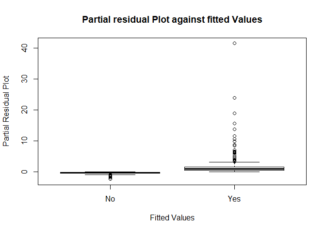

```r
#resid(forward2)
#forward2$residuals

# partial residual plot against fitted values (explanatory variable)
plot(residuals(forward2, type="pearson") ~ talentManage1$Attrition, main="Partial residual Plot against fitted Values", xlab="Fitted Values", ylab="Partial Residual Plot")
```

```r
#Std.resid and cooks distance broom package augment
model.data <- augment(forward2) %>%
  mutate(index = 1:n())
```

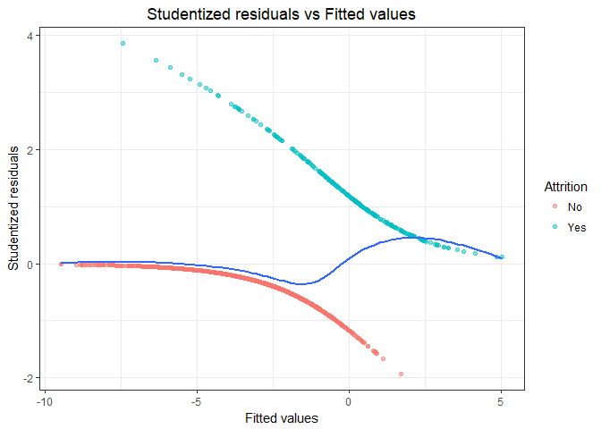

```r
#Plot the standardized residuals:
ggplot(forward2, aes(.fitted, .resid)) +
  geom_point(aes(color = Attrition), alpha = .5) +
  theme_bw()+
  labs(title="Studentized residuals vs Fitted values", x="Fitted values", y="Studentized residuals")+
  geom_smooth(se=F) +
  theme(plot.title = element_text(hjust = 0.5))
```

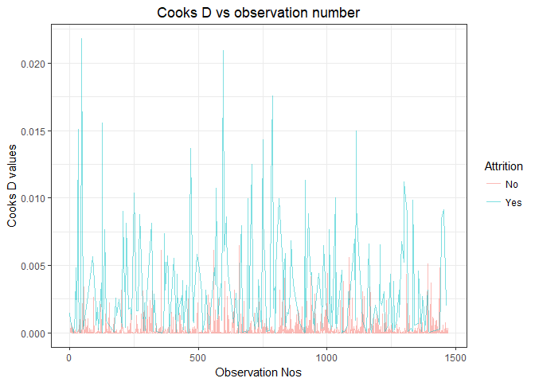

```r
ggplot(forward2, aes(seq_along(.cooksd), .cooksd)) +
  geom_line(aes(color = Attrition), alpha = .5) +
  theme_bw()+
  labs(title="Cooks D vs observation number", x="Observation Nos", y="Cooks D values") +
  theme(plot.title = element_text(hjust = 0.5))
```

```r
#The data for the top 3 largest values, according to the Cook's distance, can be displayed as follow
model.data %>% top_n(3, .cooksd)
```

```
##   Attrition OverTime           JobRole StckOptnLvl EnvrnmntSts
## 1       Yes       No Research Director           0           2
## 2       Yes      Yes Research Director           0           4
## 3       Yes       No   Human Resources           1           2
##     BusinssTrvl JobInvlvmnt DistncFrmHm JobSatsfctn NmCmpnsWrkd
## 1 Travel_Rarely           3          12           3           1
## 2 Travel_Rarely           3           2           2           7
## 3 Travel_Rarely           2           1           1           9
##   TtlWrkngYrs WorkLifBlnc RltnshpStsf YrsSncLstPr logMthlyInc YrsInCrrntR
## 1          23           3           4          15    9.880475          15
## 2          40           3           4          13    9.865059          15
## 3          24           3           4           3    9.257415           6
##        EducatinFld TrnngTmsLsY Gender YrsWthCrrMn DailyRate Age   .fitted
## 1 Technical Degree           0 Female           8      1360  41 -3.075260
## 2    Life Sciences           2   Male           8       286  58 -3.154119
## 3          Medical           1   Male           6      1376  44 -3.775090
##    .se.fit   .resid       .hat    .sigma    .cooksd .std.resid index
## 1 1.106409 2.498160 0.05164791 0.7507164 0.02181760   2.565284    46
## 2 1.085629 2.528205 0.04626453 0.7506593 0.02090903   2.588799   596
## 3 1.001198 2.755999 0.02197066 0.7501570 0.01756973   2.786783   790
```

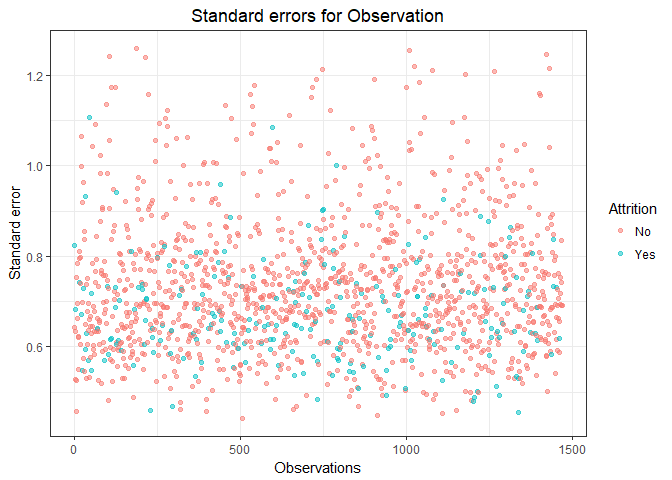

```r
ggplot(model.data, aes(index, .se.fit)) +
  geom_point(aes(color = Attrition), alpha = .5) +
  theme_bw()+
  labs(title="Standard errors for Observation", x="Observations", y="Standard error") +
  theme(plot.title = element_text(hjust = 0.5))
```

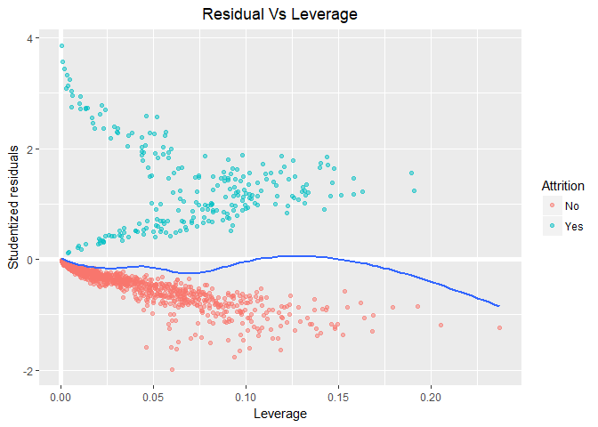

```r
# Residual Vs Leverage
ggplot(forward2, aes(.hat, .stdresid)) +
  geom_vline(size = 2, colour = "white", xintercept = 0) +
  geom_hline(size = 2, colour = "white", yintercept = 0) +
  geom_point(aes(color = Attrition), alpha = .5) + geom_smooth(se = FALSE) +
  labs(title="Residual Vs Leverage", x="Leverage", y="Studentized residuals") +
  theme(plot.title = element_text(hjust = 0.5))
```

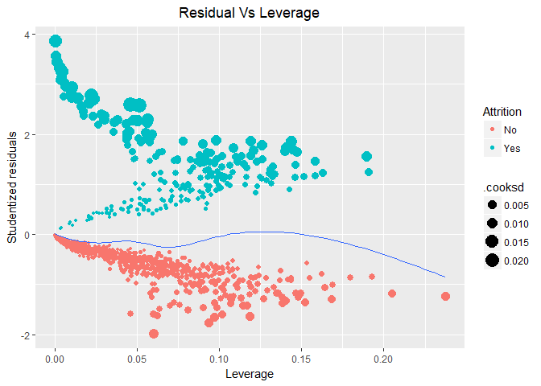

```r
ggplot(forward2, aes(.hat, .stdresid)) +
  geom_point(aes(size = .cooksd, color = Attrition)) +
  geom_smooth(se = FALSE, size = 0.5) +
  labs(title="Residual Vs Leverage", x="Leverage", y="Studentized residuals") +
  theme(plot.title = element_text(hjust = 0.5))
```

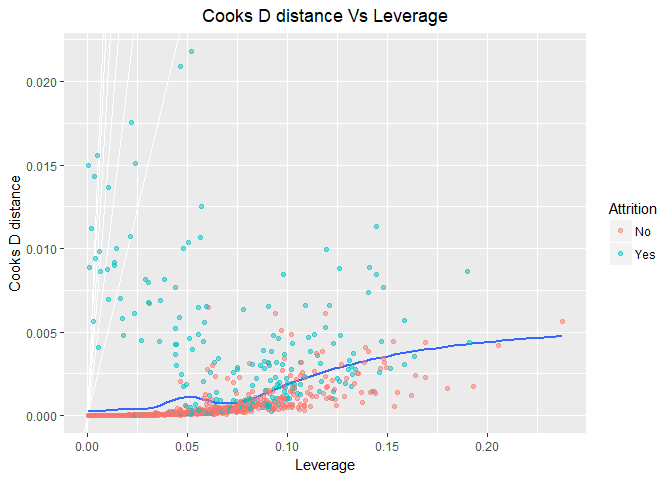

```r
# Cooks distance Vs Leverage

ggplot(forward2, aes(.hat, .cooksd)) +
  geom_vline(xintercept = 0, colour = NA) +
  geom_abline(slope = seq(0, 3, by = 0.5), colour = "white") +
  geom_smooth(se = FALSE) +
  geom_point(aes(color = Attrition), alpha = .5) +
  labs(title="Cooks D distance Vs Leverage", x="Leverage", y="Cooks D distance") +
    theme(plot.title = element_text(hjust = 0.5))
```

b Create bar charts in ggplot or similar. The bars should be in descending order, Use any color palette of your choice other than the default.

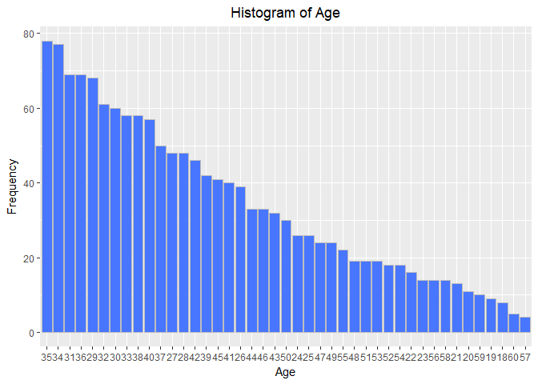

```r
#age histogram
age_hist <- as.data.frame.table(table(talentManage$Age))

ggplot(data = age_hist, mapping = aes(x=reorder(Var1, -Freq), y=Freq)) +
  geom_bar(stat="identity", col = "gray", fill = "royalblue1" ) +
  labs(x = "Age", y = "Frequency", title = "Histogram of Age") +
  theme(plot.title = element_text(hjust = 0.5))
```

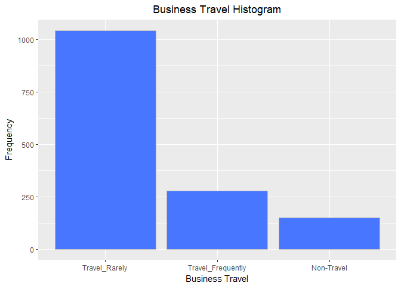

```r
#Bsiness Travel histogram
BusinssTrvl_hist <- as.data.frame.table(table(talentManage$BusinssTrvl))

ggplot(data = BusinssTrvl_hist, mapping = aes(x=reorder(Var1, -Freq), y=Freq)) +
  geom_bar(stat="identity", col = "gray", fill = "royalblue1" ) +
  labs(x = "Business Travel", y = "Frequency", title = "Business Travel Histogram") +
  theme(plot.title = element_text(hjust = 0.5))
```

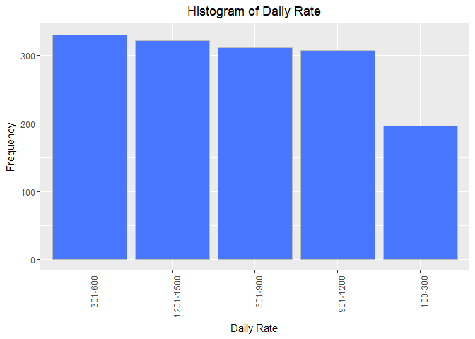

```r
#Daily Rate histogram

DailyRate <- cut(talentManage[,c("DailyRate")], breaks = c(100,300,600,900,1200,1500), labels = c("100-300", "301-600", "601-900", "901-1200", "1201-1500"), right = TRUE, include.lowest = TRUE, ordered_result = TRUE)

DailyRate_hist <- as.data.frame.table(table(DailyRate))

ggplot(data = DailyRate_hist, mapping = aes(x=reorder(DailyRate, -Freq), y=Freq)) +
  geom_bar(stat="identity", col = "gray", fill = "royalblue1" ) +
  labs(x = "Daily Rate", y = "Frequency", title = "Histogram of Daily Rate") +
  theme(plot.title = element_text(hjust = 0.5)) +
  theme(axis.text.x = element_text(angle = 90, hjust = 1))
```

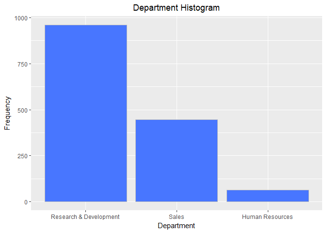

```r
#Department histogram
Department_hist <- as.data.frame.table(table(talentManage$Department))

ggplot(data = Department_hist, mapping = aes(x=reorder(Var1, -Freq), y=Freq)) +
  geom_bar(stat="identity", col = "gray", fill = "royalblue1" ) +
  labs(x = "Department", y = "Frequency", title = "Department Histogram") +
  theme(plot.title = element_text(hjust = 0.5))
```

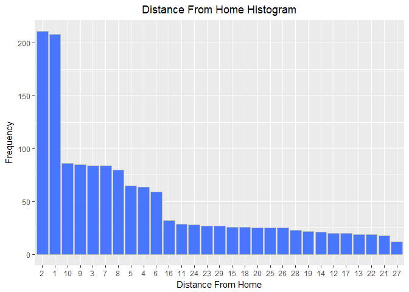

```r
#Distance From Home histogram
DistncFrmHm_hist <- as.data.frame.table(table(talentManage$DistncFrmHm))

ggplot(data = DistncFrmHm_hist, mapping = aes(x=reorder(Var1, -Freq), y=Freq)) +
  geom_bar(stat="identity", col = "gray", fill = "royalblue1" ) +
  labs(x = "Distance From Home", y = "Frequency", title = "Distance From Home Histogram") +
  theme(plot.title = element_text(hjust = 0.5))
```

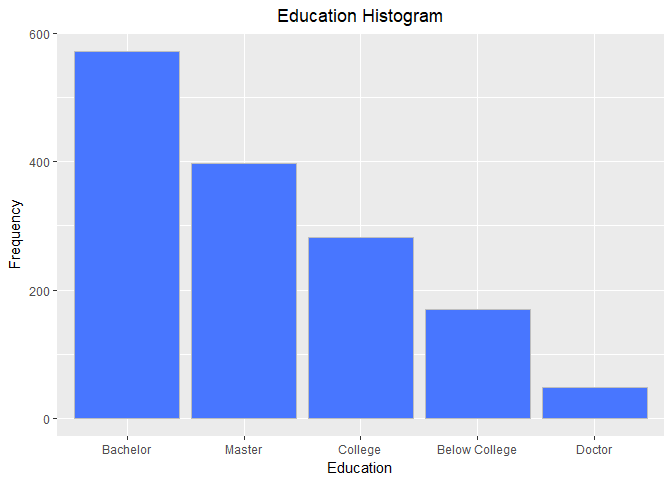

```r
#Education histogram
Education_hist <- as.data.frame.table(table(talentManage$Education))

ggplot(data = Education_hist, mapping = aes(x=reorder(Var1, -Freq), y=Freq)) +
  geom_bar(stat="identity", col = "gray", fill = "royalblue1" ) +
  labs(x = "Education", y = "Frequency", title = "Education Histogram") +
  theme(plot.title = element_text(hjust = 0.5))
```

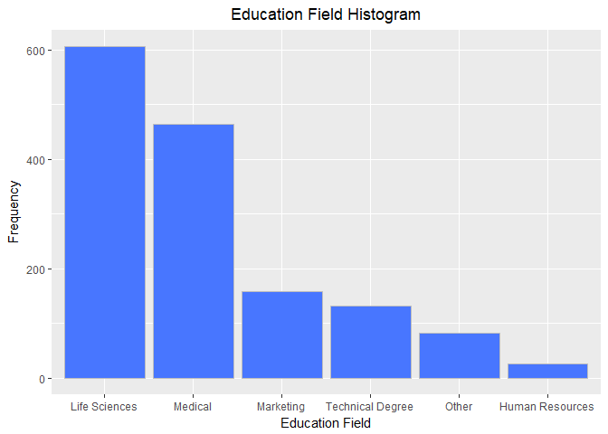

```r
#Education Field histogram
EducatinFld_hist <- as.data.frame.table(table(talentManage$EducatinFld))

ggplot(data = EducatinFld_hist, mapping = aes(x=reorder(Var1, -Freq), y=Freq)) +
  geom_bar(stat="identity", col = "gray", fill = "royalblue1" ) +
  labs(x = "Education Field", y = "Frequency", title = "Education Field Histogram") +
  theme(plot.title = element_text(hjust = 0.5))
```

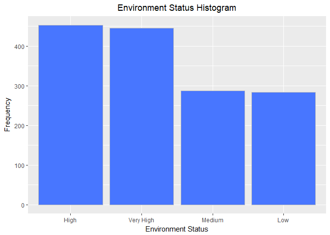

```r
#Environemnt Status histogram
EnvrnmntSts_hist <- as.data.frame.table(table(talentManage$EnvrnmntSts))

ggplot(data = EnvrnmntSts_hist, mapping = aes(x=reorder(Var1, -Freq), y=Freq)) +
  geom_bar(stat="identity", col = "gray", fill = "royalblue1" ) +
  labs(x = "Environment Status", y = "Frequency", title = "Environment Status Histogram") +
  theme(plot.title = element_text(hjust = 0.5))
```

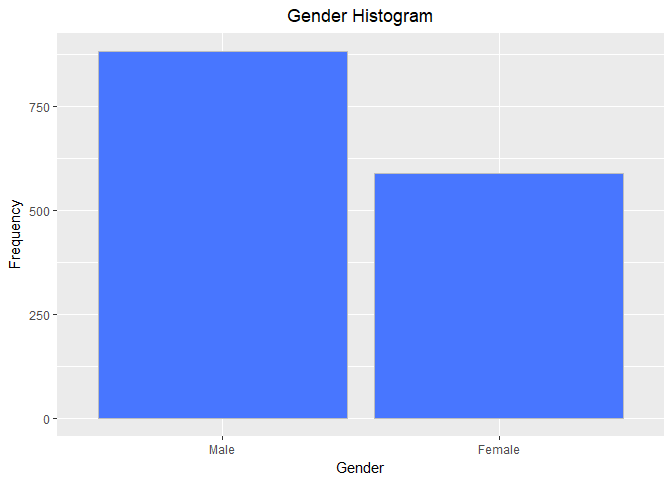

```r
#Gender histogram
Gender_hist <- as.data.frame.table(table(talentManage$Gender))

ggplot(data = Gender_hist, mapping = aes(x=reorder(Var1, -Freq), y=Freq)) +
  geom_bar(stat="identity", col = "gray", fill = "royalblue1" ) +
  labs(x = "Gender", y = "Frequency", title = "Gender Histogram") +
  theme(plot.title = element_text(hjust = 0.5))
```

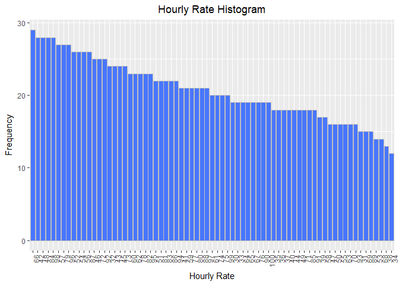

```r
#Hourly Rate histogram
HourlyRate_hist <- as.data.frame.table(table(talentManage$HourlyRate))

ggplot(data = HourlyRate_hist, mapping = aes(x=reorder(Var1, -Freq), y=Freq)) +
  geom_bar(stat="identity", col = "gray", fill = "royalblue1" ) +
  labs(x = "Hourly Rate", y = "Frequency", title = "Hourly Rate Histogram") +
  theme(plot.title = element_text(hjust = 0.5), axis.text.x = element_text(angle=90, hjust=1))
```

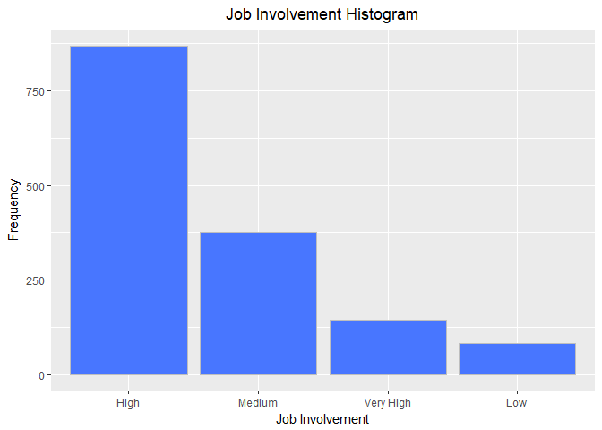

```r
#Job Involvement histogram
JobInvlvmnt_hist <- as.data.frame.table(table(talentManage$JobInvlvmnt))

ggplot(data = JobInvlvmnt_hist, mapping = aes(x=reorder(Var1, -Freq), y=Freq)) +
  geom_bar(stat="identity", col = "gray", fill = "royalblue1" ) +
  labs(x = "Job Involvement", y = "Frequency", title = "Job Involvement Histogram") +
  theme(plot.title = element_text(hjust = 0.5))
```

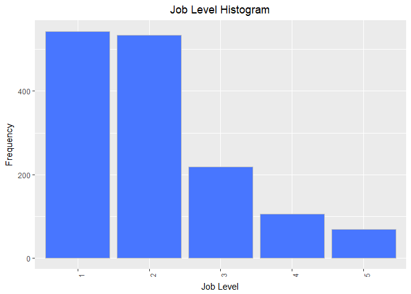

```r
#Job Level histogram
JobLevel_hist <- as.data.frame.table(table(talentManage$JobLevel))

ggplot(data = JobLevel_hist, mapping = aes(x=reorder(Var1, -Freq), y=Freq)) +
  geom_bar(stat="identity", col = "gray", fill = "royalblue1" ) +
  labs(x = "Job Level", y = "Frequency", title = "Job Level Histogram") +
  theme(plot.title = element_text(hjust = 0.5), axis.text.x = element_text(angle=90, hjust=1))
```

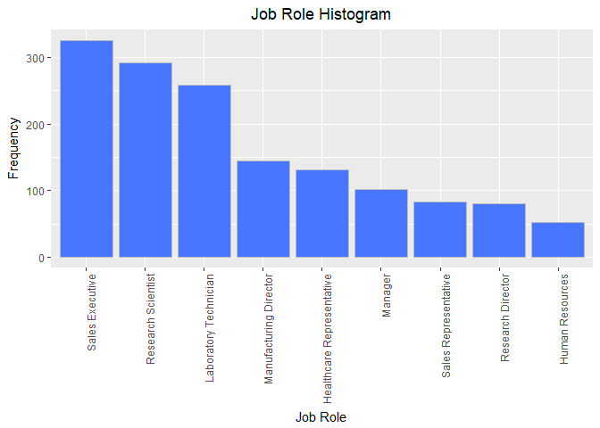

```r
#Job Role histogram
JobRole_hist <- as.data.frame.table(table(talentManage$JobRole))

ggplot(data = JobRole_hist, mapping = aes(x=reorder(Var1, -Freq), y=Freq)) +
  geom_bar(stat="identity", col = "gray", fill = "royalblue1" ) +
  labs(x = "Job Role", y = "Frequency", title = "Job Role Histogram") +
  theme(plot.title = element_text(hjust = 0.5), axis.text.x = element_text(angle=90, hjust=1))
```

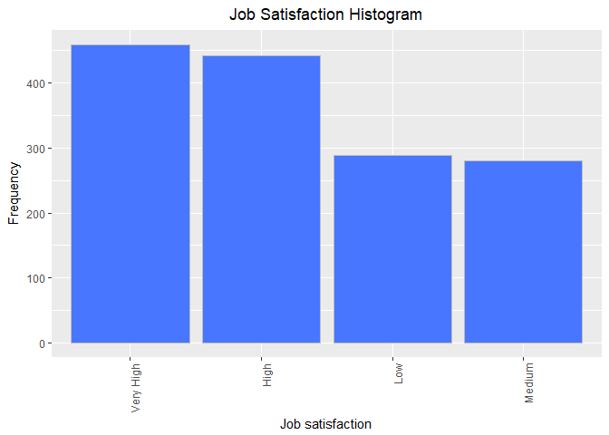

```r
#Job Satisfaction histogram
JobSatsfctn_hist <- as.data.frame.table(table(talentManage$JobSatsfctn))

ggplot(data = JobSatsfctn_hist, mapping = aes(x=reorder(Var1, -Freq), y=Freq)) +
  geom_bar(stat="identity", col = "gray", fill = "royalblue1" ) +
  labs(x = "Job satisfaction", y = "Frequency", title = "Job Satisfaction Histogram") +
  theme(plot.title = element_text(hjust = 0.5), axis.text.x = element_text(angle=90, hjust=1))
```

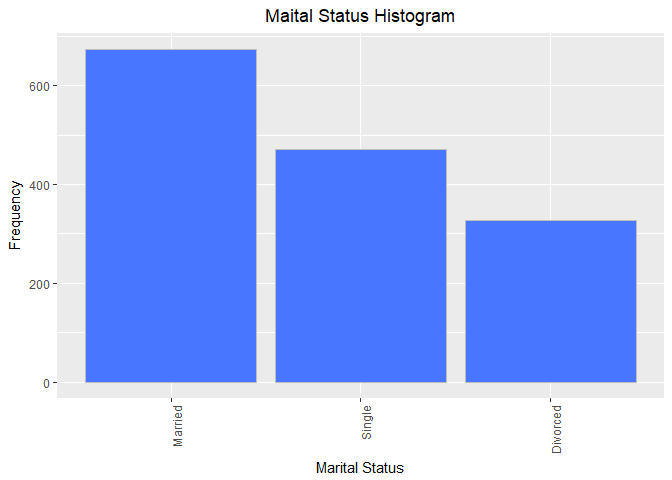

```r
#Marital Status histogram
MaritalStts_hist <- as.data.frame.table(table(talentManage$MaritalStts))

ggplot(data = MaritalStts_hist, mapping = aes(x=reorder(Var1, -Freq), y=Freq)) +
  geom_bar(stat="identity", col = "gray", fill = "royalblue1" ) +
  labs(x = "Marital Status", y = "Frequency", title = "Maital Status Histogram") +
  theme(plot.title = element_text(hjust = 0.5), axis.text.x = element_text(angle=90, hjust=1))
```

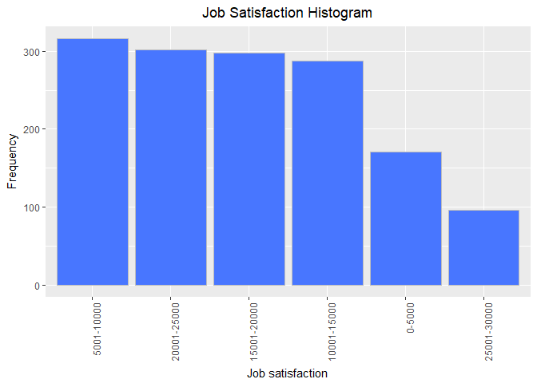

```r
#Job Satisfaction histogram

MonthlyRate <- cut(talentManage[,c("MonthlyRate")], breaks = c(0,5000,10000,15000,20000,25000, 30000), labels = c("0-5000", "5001-10000", "10001-15000", "15001-20000", "20001-25000", "25001-30000"), right = TRUE, include.lowest = TRUE, ordered_result = TRUE)

MonthlyRate_hist <- as.data.frame.table(table(MonthlyRate))

ggplot(data = MonthlyRate_hist, mapping = aes(x=reorder(MonthlyRate, -Freq), y=Freq)) +
  geom_bar(stat="identity", col = "gray", fill = "royalblue1" ) +
  labs(x = "Job satisfaction", y = "Frequency", title = "Job Satisfaction Histogram") +
  theme(plot.title = element_text(hjust = 0.5), axis.text.x = element_text(angle=90, hjust=1))
```

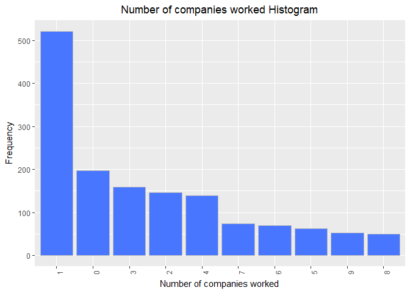

```r
#Number of Companies worked histogram
NmCmpnsWrkd_hist <- as.data.frame.table(table(talentManage$NmCmpnsWrkd))

ggplot(data = NmCmpnsWrkd_hist, mapping = aes(x=reorder(Var1, -Freq), y=Freq)) +
  geom_bar(stat="identity", col = "gray", fill = "royalblue1" ) +
  labs(x = "Number of companies worked", y = "Frequency", title = "Number of companies worked Histogram") +
  theme(plot.title = element_text(hjust = 0.5), axis.text.x = element_text(angle=90, hjust=1))
```

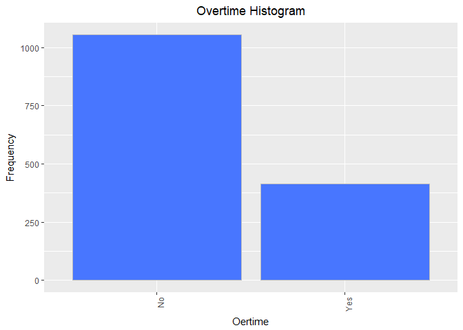

```r
#Overtime histogram
OverTime_hist <- as.data.frame.table(table(talentManage$OverTime))

ggplot(data = OverTime_hist, mapping = aes(x=reorder(Var1, -Freq), y=Freq)) +
  geom_bar(stat="identity", col = "gray", fill = "royalblue1" ) +
  labs(x = "Oertime", y = "Frequency", title = "Overtime Histogram") +
  theme(plot.title = element_text(hjust = 0.5), axis.text.x = element_text(angle=90, hjust=1))
```

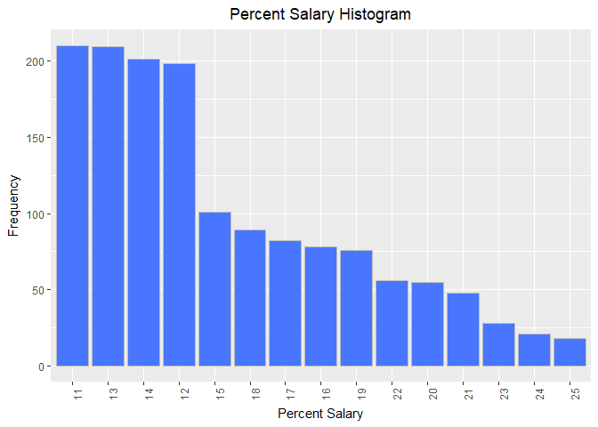

```r
#Percent Salary Hike histogram
PrcntSlryHk_hist <- as.data.frame.table(table(talentManage$PrcntSlryHk))

ggplot(data = PrcntSlryHk_hist, mapping = aes(x=reorder(Var1, -Freq), y=Freq)) +
  geom_bar(stat="identity", col = "gray", fill = "royalblue1" ) +
  labs(x = "Percent Salary", y = "Frequency", title = "Percent Salary Histogram") +
  theme(plot.title = element_text(hjust = 0.5), axis.text.x = element_text(angle=90, hjust=1))
```

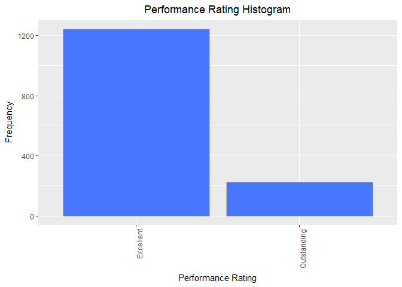

```r
#Performance rating histogram
PrfrmncRtng_hist <- as.data.frame.table(table(talentManage$PrfrmncRtng))

ggplot(data = PrfrmncRtng_hist, mapping = aes(x=reorder(Var1, -Freq), y=Freq)) +
  geom_bar(stat="identity", col = "gray", fill = "royalblue1" ) +
  labs(x = "Performance Rating", y = "Frequency", title = "Performance Rating Histogram") +
  theme(plot.title = element_text(hjust = 0.5), axis.text.x = element_text(angle=90, hjust=1))
```

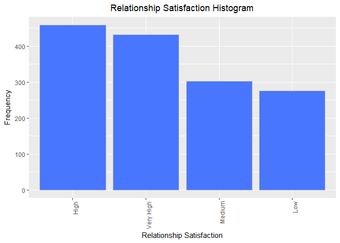

```r
#Relationship Satisfaction histogram
RltnshpStsf_hist <- as.data.frame.table(table(talentManage$RltnshpStsf))

ggplot(data = RltnshpStsf_hist, mapping = aes(x=reorder(Var1, -Freq), y=Freq)) +
  geom_bar(stat="identity", col = "gray", fill = "royalblue1" ) +
  labs(x = "Relationship Satisfaction", y = "Frequency", title = "Relationship Satisfaction Histogram") +
  theme(plot.title = element_text(hjust = 0.5), axis.text.x = element_text(angle=90, hjust=1))
```

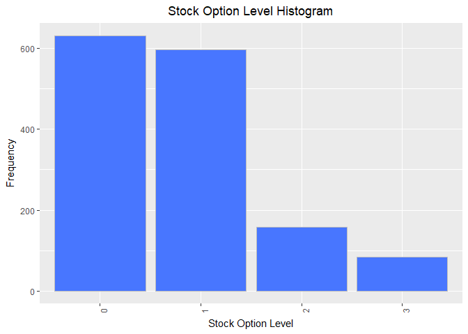

```r
#Standard Hours histogram
#StandardHrs_hist <- as.data.frame.table(table(talentManage$StandardHrs))

#ggplot(data = StandardHrs_hist, mapping = aes(x=reorder(Var1, -Freq), y=Freq)) +
#  geom_bar(stat="identity", col = "gray", fill = "royalblue1" ) +
#  labs(x = "Standard Hours", y = "Frequency", title = "Standard Hours Histogram") +
#  theme(plot.title = element_text(hjust = 0.5), axis.text.x = element_text(angle=90, hjust=1))

#Stock Option Level histogram
StckOptnLvl_hist <- as.data.frame.table(table(talentManage$StckOptnLvl))

ggplot(data = StckOptnLvl_hist, mapping = aes(x=reorder(Var1, -Freq), y=Freq)) +
  geom_bar(stat="identity", col = "gray", fill = "royalblue1" ) +
  labs(x = "Stock Option Level", y = "Frequency", title = "Stock Option Level Histogram") +
  theme(plot.title = element_text(hjust = 0.5), axis.text.x = element_text(angle=90, hjust=1))
```

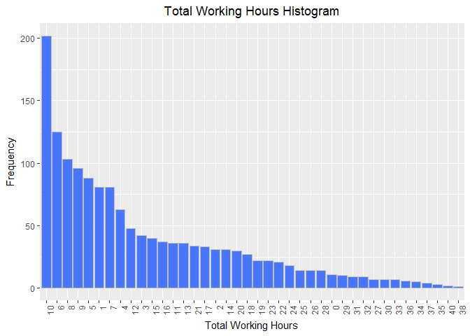

```r
#Total Working years histogram
TtlWrkngYrs_hist <- as.data.frame.table(table(talentManage$TtlWrkngYrs))

ggplot(data = TtlWrkngYrs_hist, mapping = aes(x=reorder(Var1, -Freq), y=Freq)) +
  geom_bar(stat="identity", col = "gray", fill = "royalblue1" ) +
  labs(x = "Total Working Hours", y = "Frequency", title = "Total Working Hours Histogram") +
  theme(plot.title = element_text(hjust = 0.5), axis.text.x = element_text(angle=90, hjust=1))
```

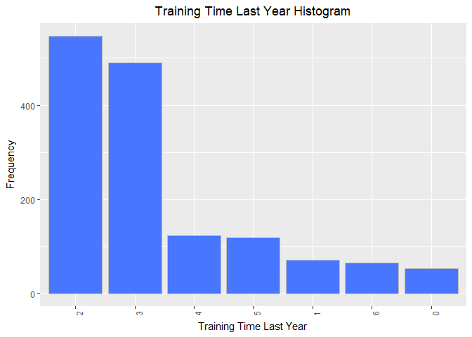

```r
#Training Time Last Year histogram
TrnngTmsLsY_hist <- as.data.frame.table(table(talentManage$TrnngTmsLsY))

ggplot(data = TrnngTmsLsY_hist, mapping = aes(x=reorder(Var1, -Freq), y=Freq)) +
  geom_bar(stat="identity", col = "gray", fill = "royalblue1" ) +
  labs(x = "Training Time Last Year", y = "Frequency", title = "Training Time Last Year Histogram") +
  theme(plot.title = element_text(hjust = 0.5), axis.text.x = element_text(angle=90, hjust=1))
```

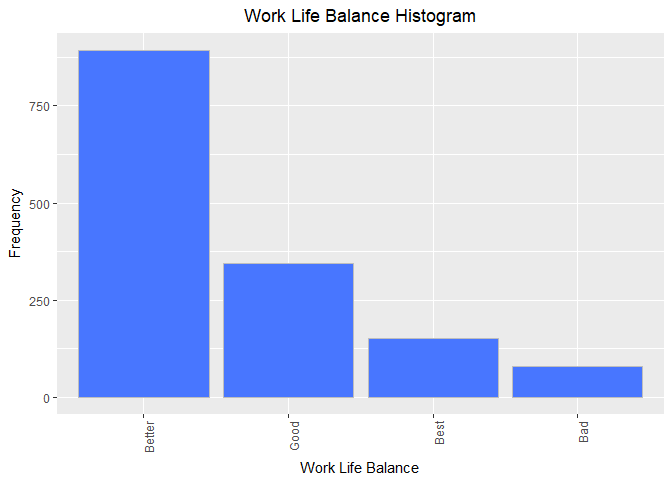

```r
#Work Life Balance histogram
WorkLifBlnc_hist <- as.data.frame.table(table(talentManage$WorkLifBlnc))

ggplot(data = WorkLifBlnc_hist, mapping = aes(x=reorder(Var1, -Freq), y=Freq)) +
  geom_bar(stat="identity", col = "gray", fill = "royalblue1" ) +
  labs(x = "Work Life Balance", y = "Frequency", title = "Work Life Balance Histogram") +
  theme(plot.title = element_text(hjust = 0.5), axis.text.x = element_text(angle=90, hjust=1))
```

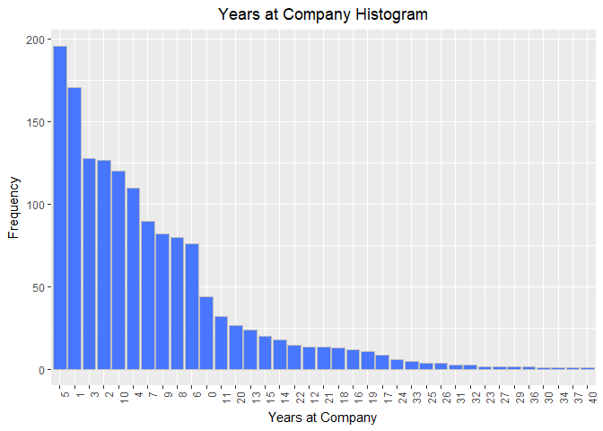

```r
#Years at company histogram
YersAtCmpny_hist <- as.data.frame.table(table(talentManage$YersAtCmpny))

ggplot(data = YersAtCmpny_hist, mapping = aes(x=reorder(Var1, -Freq), y=Freq)) +
  geom_bar(stat="identity", col = "gray", fill = "royalblue1" ) +
  labs(x = "Years at Company", y = "Frequency", title = "Years at Company Histogram") +
  theme(plot.title = element_text(hjust = 0.5), axis.text.x = element_text(angle=90, hjust=1))
```

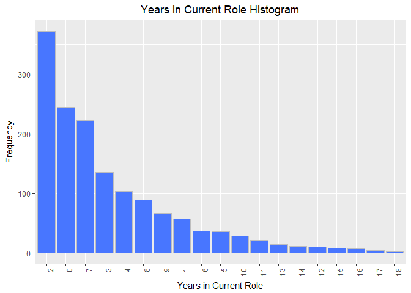

```r
#Years in current role histogram
YrsInCrrntR_hist <- as.data.frame.table(table(talentManage$YrsInCrrntR))

ggplot(data = YrsInCrrntR_hist, mapping = aes(x=reorder(Var1, -Freq), y=Freq)) +
  geom_bar(stat="identity", col = "gray", fill = "royalblue1" ) +
  labs(x = "Years in Current Role", y = "Frequency", title = "Years in Current Role Histogram") +
  theme(plot.title = element_text(hjust = 0.5), axis.text.x = element_text(angle=90, hjust=1))
```

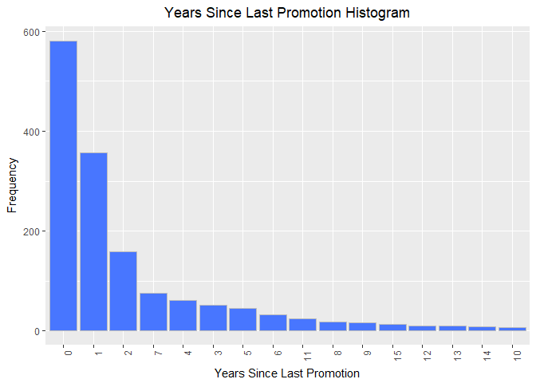

```r
#Years since last promotion histogram
YrsSncLstPr_hist <- as.data.frame.table(table(talentManage$YrsSncLstPr))

ggplot(data = YrsSncLstPr_hist, mapping = aes(x=reorder(Var1, -Freq), y=Freq)) +
  geom_bar(stat="identity", col = "gray", fill = "royalblue1" ) +
  labs(x = "Years Since Last Promotion", y = "Frequency", title = "Years Since Last Promotion Histogram") +
  theme(plot.title = element_text(hjust = 0.5), axis.text.x = element_text(angle=90, hjust=1))
```

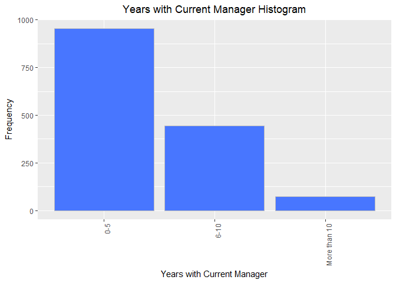

```r
#Years with Current Manager histogram
YrsWthCrrMn_hist <- as.data.frame.table(table(talentManage$YrsWthCrrMn))

ggplot(data = YrsWthCrrMn_hist, mapping = aes(x=reorder(Var1, -Freq), y=Freq)) +
  geom_bar(stat="identity", col = "gray", fill = "royalblue1" ) +
  labs(x = "Years with Current Manager", y = "Frequency", title = "Years with Current Manager Histogram") +
  theme(plot.title = element_text(hjust = 0.5), axis.text.x = element_text(angle=90, hjust=1))
```

c Is there a relationship between Age and Income? Create a scatterplot and make an assessment of whether there is a relationship. Color each point based on the Gender of the participant. You’re welcome to use lm() or similar functions to back up your claims.

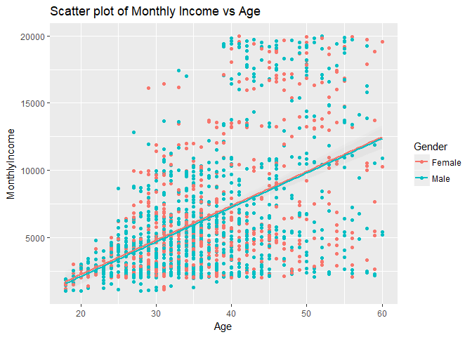

```r
ggplot(talentManage1, aes(Age, MonthlyIncome, color=Gender)) +
  geom_point() +
  labs(title="Scatter plot of Monthly Income vs Age", xlab="Age", ylab="Monthly Income")+
  geom_smooth(method="lm", alpha=0.05)
```

d What about Life Satisfaction? Create another scatterplot. Is there a discernible relationship there to what?

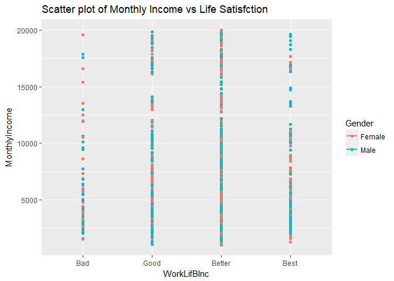

```r
ggplot(talentManage, aes(WorkLifBlnc, MonthlyIncome, color=Gender)) +
  geom_point() +
  labs(title="Scatter plot of Monthly Income vs Life Satisfction", xlab="Life Satisfaction", ylab="Monthly Income")+
  geom_smooth(method="lm", alpha=0.05) +
  geom_abline()
```